# MODULO E.4: Regressão Linear Múltipla

Modelo Completo

# 1. ANTES DA ANALISE

## 1.1) Pergunta de investigação

Quais são os determinantes da permanencia dos ministros no governo?

## 1.2) Especificação do módelo

> $$duração = b0 + b1*lealdade + b2*idade+
> b3*sexo$$
- **H0**: Efeito de Xs em $Y = 0$ .  
  O efeito é nulo. Não há relação entre nível del lealdade/idade/sexo dos ministros e a duração do ministro no governo.
- **HA**: Efeito de Xs em $Y != 0$.  
  Pelo menos uma X está relacionada com a variação da duração dos ministros no governo

# 2. ANALISE

## 2.1 Exploração das variáveis

### a) Identificar potenciais problemas

#### (i) Erros de codificação

(ex “99” vs “9.9”; “male” vs “Male”),

#### (ii) NAs

```
##        id           duração         lealdade                especialista
##  Min.   : 1.00   Min.   : 80.0   Min.   :0.0000   especialista    :7
##  1st Qu.: 4.75   1st Qu.:110.0   1st Qu.:0.2500   não-especialista:9
##  Median : 8.50   Median :145.0   Median :0.6250
##  Mean   : 8.50   Mean   :154.4   Mean   :0.5938
##  3rd Qu.:12.25   3rd Qu.:200.0   3rd Qu.:1.0000
##  Max.   :16.00   Max.   :240.0   Max.   :1.0000
##
##     pasta               sexo.d        idade           idadeB      partido
##  Length:16          Min.   :0.0   Min.   :18.00   Min.   :18.00   Ind:5
##  Class :character   1st Qu.:0.0   1st Qu.:30.75   1st Qu.:30.25   PL :5
##  Mode  :character   Median :0.5   Median :42.50   Median :42.50   PS :6
##                     Mean   :0.5   Mean   :46.88   Mean   :46.36
##                     3rd Qu.:1.0   3rd Qu.:62.75   3rd Qu.:66.25
##                     Max.   :1.0   Max.   :75.00   Max.   :75.00
##                                                   NA's   :2
##      sexo     educacao
##  female:8   Length:16
##  male  :8   Class :character
##             Mode  :character
##
##
##
##
```

#### (iii) Outliers

**duração**

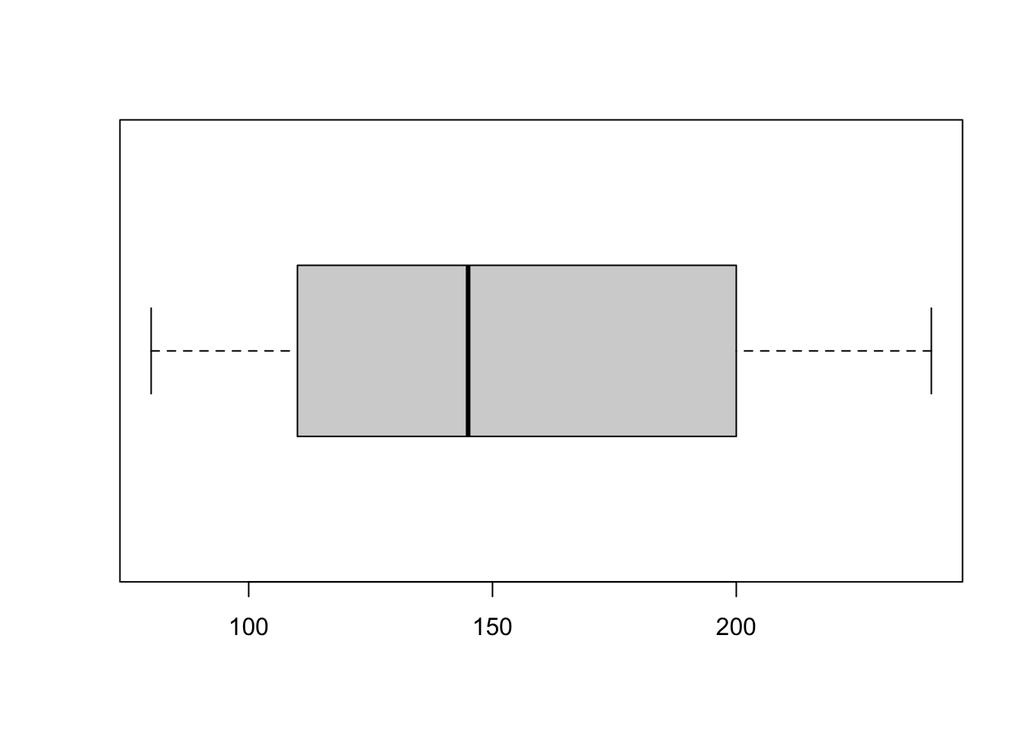

```
## numeric(0)
```

**lealdade**

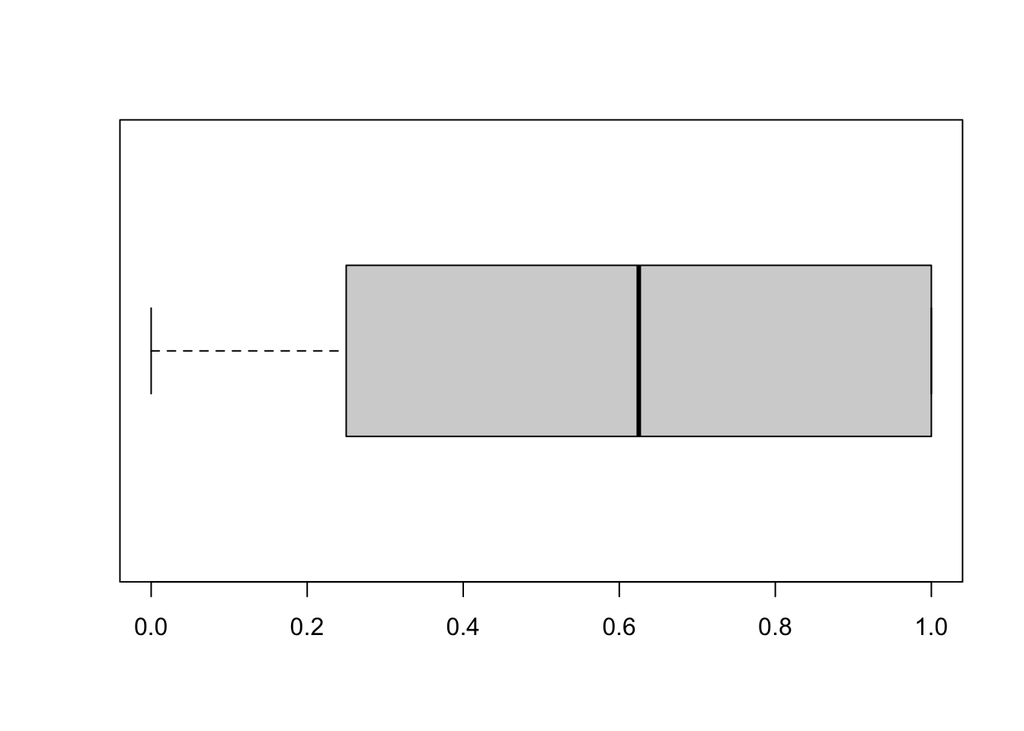

```
## numeric(0)
```

**idade**

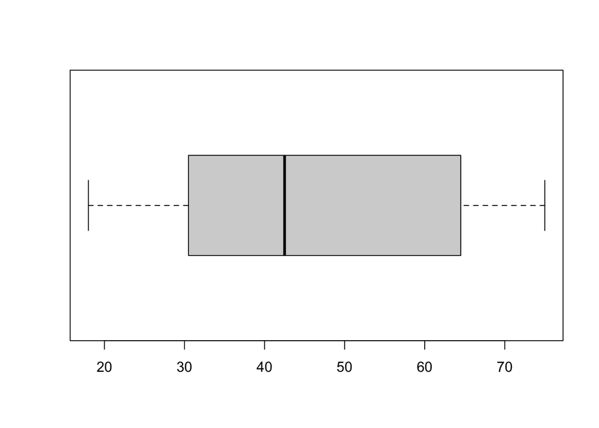

```
## numeric(0)
```

**sexo**

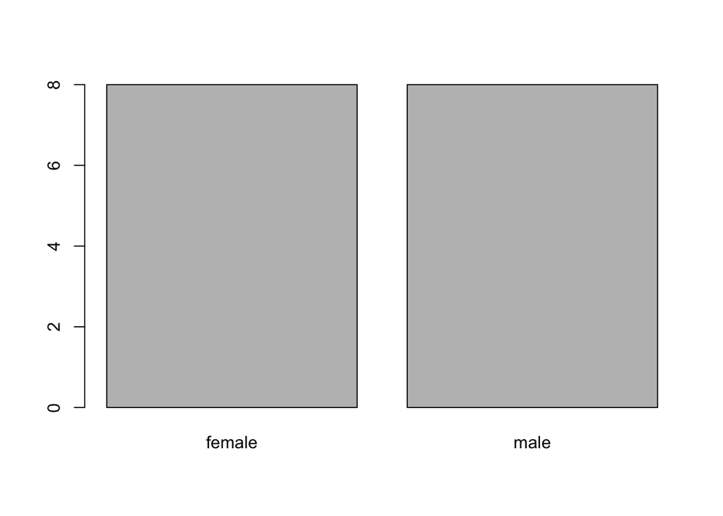

#### (v): Normalidade da distribuição

É preferivel uma distribuição perto da normal distribuição, não estando corrida (skewed) para a esquerda ou direita.

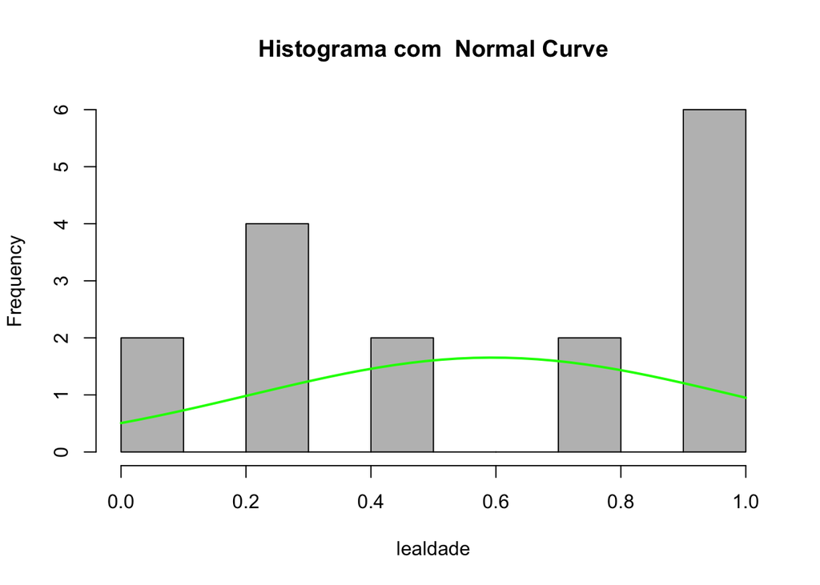

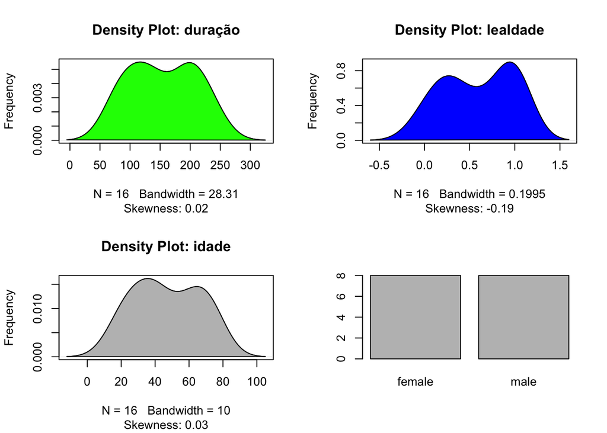

- **Symmetric**: Values between -0.5 to 0.5
- **Moderated Skewed data**: Values between -1 and -0.5 or between 0.5 and 1
- **Highly Skewed data**: Values less than -1 or greater than 1

#### (iv) Relação VI-VD linear

A relação entre as VIs numéricas e a DV deve ser linear

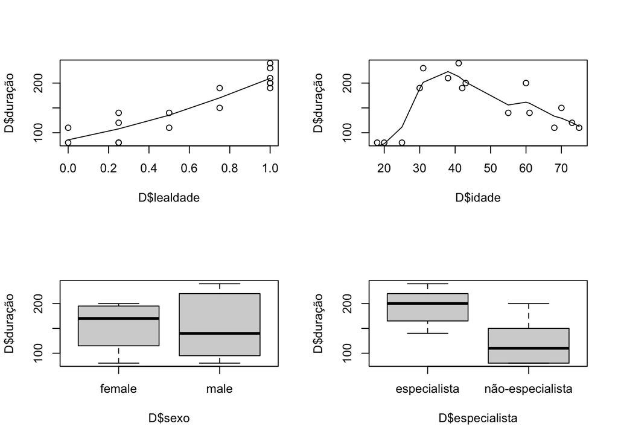

O gráfico de dispersão junto com a `smoothing line` acima sugere uma relação linear crescente entre as variáveis ‘lealdade’ e ‘duração’, em conformidade com o pressuposto de linearidade. Não acontence o mesmo com ‘idade’.

##### Correlação

*lealdadad/duração*

```
##
##  Pearson's product-moment correlation
##
## data:  D$lealdade and D$duração
## t = 8.1966, df = 14, p-value = 1.031e-06
## alternative hypothesis: true correlation is not equal to 0
## 95 percent confidence interval:
##  0.7540074 0.9686146
## sample estimates:
##       cor
## 0.9096987
```

```
##
##  Pearson's product-moment correlation
##
## data:  D$idade and D$duração
## t = -0.066213, df = 14, p-value = 0.9481
## alternative hypothesis: true correlation is not equal to 0
## 95 percent confidence interval:
##  -0.5089350  0.4822415
## sample estimates:
##         cor
## -0.01769345
```

##### Regressões simples

*lealdadad/duração*

```
##
## Call:
## lm(formula = duração ~ lealdade, data = D)
##
## Residuals:
##    Min     1Q Median     3Q    Max
## -32.27 -18.75   0.00  17.39  33.18
##
## Coefficients:
##             Estimate Std. Error t value Pr(>|t|)
## (Intercept)    77.73      11.05   7.035 5.91e-06 ***
## lealdade      129.09      15.75   8.197 1.03e-06 ***
## ---
## Signif. codes:  0 '***' 0.001 '**' 0.01 '*' 0.05 '.' 0.1 ' ' 1
##
## Residual standard error: 23.54 on 14 degrees of freedom
## Multiple R-squared:  0.8276, Adjusted R-squared:  0.8152
## F-statistic: 67.18 on 1 and 14 DF,  p-value: 1.031e-06
```

```
##
## Call:
## lm(formula = duração ~ sexo, data = D)
##
## Residuals:
##     Min      1Q  Median      3Q     Max
## -75.000 -44.063  -9.375  45.000  86.250
##
## Coefficients:
##             Estimate Std. Error t value Pr(>|t|)
## (Intercept)   155.00      20.04   7.734 2.03e-06 ***
## sexomale       -1.25      28.34  -0.044    0.965
## ---
## Signif. codes:  0 '***' 0.001 '**' 0.01 '*' 0.05 '.' 0.1 ' ' 1
##
## Residual standard error: 56.69 on 14 degrees of freedom
## Multiple R-squared:  0.0001389,  Adjusted R-squared:  -0.07128
## F-statistic: 0.001945 on 1 and 14 DF,  p-value: 0.9654
```

```
##
## Call:
## lm(formula = duração ~ idade, data = D)
##
## Residuals:
##     Min      1Q  Median      3Q     Max
## -75.821 -43.054  -8.442  45.644  85.331
##
## Coefficients:
##              Estimate Std. Error t value Pr(>|t|)
## (Intercept) 156.72261   38.18222   4.105  0.00107 **
## idade        -0.05008    0.75638  -0.066  0.94814
## ---
## Signif. codes:  0 '***' 0.001 '**' 0.01 '*' 0.05 '.' 0.1 ' ' 1
##
## Residual standard error: 56.68 on 14 degrees of freedom
## Multiple R-squared:  0.0003131,  Adjusted R-squared:  -0.07109
## F-statistic: 0.004384 on 1 and 14 DF,  p-value: 0.9481
```

## 2.2 Estimação do Modelo

>
$$duração = b0 + b1*lealdade + b2*idade+
b3*sexo$$

```
##
## Call:
## lm(formula = duração ~ lealdade + sexo + idade, data = D)
##
## Residuals:
##     Min      1Q  Median      3Q     Max
## -32.088 -14.096   1.428  15.159  29.454
##
## Coefficients:
##             Estimate Std. Error t value Pr(>|t|)
## (Intercept)  39.9696    19.5070   2.049   0.0630 .
## lealdade    140.1877    13.9912  10.020 3.51e-07 ***
## sexomale     27.8834    10.6404   2.621   0.0224 *
## idade         0.3675     0.2761   1.331   0.2079
## ---
## Signif. codes:  0 '***' 0.001 '**' 0.01 '*' 0.05 '.' 0.1 ' ' 1
##
## Residual standard error: 20 on 12 degrees of freedom
## Multiple R-squared:  0.8933, Adjusted R-squared:  0.8666
## F-statistic: 33.49 on 3 and 12 DF,  p-value: 4.126e-06
```

> Descrição do ‘output’:  
> **Call**:  
> - Mostra a função usada para calcular o modelo de regressão.  
> **Residuals**:  
> - Indica a distribuição dos resíduos, que por definição têm uma média zero. Portanto, a mediana não deve estar longe de zero, e o mínimo e o máximo devem ser aproximadamente iguais em valor absoluto.  
> **Coefficients**, mostra:  
> - as estimativas dos **coeficientes beta** ;  
> - os **erros padrão (SE)**, que definem a precisão dos coeficientes beta. Para um dado coeficiente beta, o SE reflete como o coeficiente varia sob amostragem repetida. *Pode ser usado para calcular os intervalos de confiança e a estatística t*.  
> - **a estatística t** e o **valor p** associado, que define a significância estatística dos coeficientes beta.  
> **Residual standard error (RSE)**, o erro padrão residual.  
> **Multiple R-squared** e **Adjusted R-squared**: Medidadas de qualidade do modelo.  
> **F-statistic**, estatística F, medida de adequabilidade do modelo.

## 2.3) Interpretação do Modelo

Passos da interpretação:

1. Verificar se os preditores estão significativamente associado à variável dependente.
2. Avaliar quão bem o modelo se ajusta aos dados inspecionando:  
   **RSE** : Quanto mais perto de zero, melhor  
   **R-Squared**: quanto maior, melhor  
   **F-statistic**: Quanto maior, melhor
3. Controlar os pressupostos

### 2.3.1) PREDITORES

#### i) Estimativas dos coeficientes

$$duração = 39.9696 + 140.1877 * lealdade
+ 27.8834 * sexo + 0.3675 * idade$$

O `intercept` (b0, 39.96). Pode ser interpretado como a duração no governo para um ministro com valor 0 em todas as variáveis.  
Assim, para um ministro com lealdade zero, mulher, e zero anos, o modelo prediz una media uma duração de quase 40 días.

$$duração = 39.9696 + 140.1877 * 0 +
27.8834 * 0 + 0.3675 * 0$$

```r
39.9696 + 140.1877 * 0 + 27.8834 * 0 + 0.3675 * 0
```

```
## [1] 39.9696
```

O `coeficiente beta` de regressão para a variável *`idade`* é 0.3675. Isto significa que por cada ano de idade, a duração aumenta em 0.3675 dias.  
Então, para uma ministra com 50 anos de idade, o modelo prediz uma duração de:

$$duração = 39.9696 + 140.1877 * 0 +
27.8834 * 0 + 0.3675 * 50$$

```r
39.9696 + 140.1877 * 0 + 27.8834 * 0 + 0.3675 * 50
```

```
## [1] 58.3446
```

O `coeficiente beta` de regressão para a variável *`lealdade`* é 140.1877. Por cada grau de lealdade, , a duração aumenta em mais de 140 dias.  
Para uma ministra de 50 anos ecom lealdade 4, o modelo prediz uma duração de:

$$duração = 39.9696 + 140.1877 * 4 +
27.8834 * 0 + 0.3675 * 50$$

```r
39.9696 + 140.1877 * 4 + 27.8834 * 0 + 0.3675 * 50
```

```
## [1] 619.0954
```

#### ii) Análise inferencial

- `Hipótese nula (H0)`: os coeficientes são iguais a zero (ou seja, nenhuma relação entre x e y)
- `Hipótese alternativa (Ha)`: os coeficientes não são iguais a zero (ou seja, há alguma relação entre x e y)

Para a tomada de decisão pode usar-se:  
1. O teste t e o p-value  
1. Os limites do Intervalo de Confiança (IC)

##### a) Estatística-t e valor-p dos coeficientes:

Rejeita-se a `H0` se p ≤ .05, e se concluiu o efeito de X em Y é significativo

##### b) Intervalos de confiança dos coeficientes:

Também podemos utilizar o erro padrão para calcular os intervalos de confiança de 95% para o coeficiente b1.

Rejeita-se a `H0` se o zero não pertence ao IC, e se concluiu que o efeito de X em Y é significativo

```
##                   2.5 %      97.5 %
## (Intercept)  -2.5325151  82.4716751
## lealdade    109.7035269 170.6719232
## sexomale      4.6999950  51.0668760
## idade        -0.2341131   0.9691421
```

Ou seja, há aproximadamente 95% de chance de que o intervalo contenha o valor verdadeiro de b1 e b2.

### 2.3.2) MODELO (‘goodness-of-fit’)

A qualidade geral do modelo de regressão linear pode ser avaliada usando estos três valores, exibidos no resumo do modelo:  
- O erro padrão residual (RSE, Residual Standard Error).  
- O R-quadrado (R2)  
- Estatística F

#### i) Erro padrão residual (`RSE` ou `sigma`).

O RSE (também conhecido como sigma do modelo) é a variação residual, representando a variação média dos pontos de observação em torno da linha de regressão estimada. Este é o desvio padrão dos erros residuais.

RSE fornece uma medida absoluta dos dados que não podem ser explicados pelo modelo. *Ao comparar dois modelos*, o modelo com o RSE pequeno é uma boa indicação de que esse modelo se ajusta melhor aos dados.

O *RSE* = 20.00236, o que significa que os valores de duração observados se desviam da linha de regressão verdadeira em 20 dias em média.

#### ii) R-squared e Adjusted R-squared:

O *R<sup>2</sup>* mede quão bem o modelo se ajusta aos dados, indicando a a proporção da variabilidade total explicada pelo modelo de regressão.

Para uma regressão linear simples, $R^2$ é o quadrado do coeficiente de correlação de Pearson.

```
## [1] 0.8275518
```

Um valor alto de R2 é uma boa senhal.  
No entanto, o valor de R2 a aumentar com o número de preditores. Conforme se adicionam mais variáveis X ao modelo, o valor de $R^2$ , o $R^2$ aumenta, mesmo que essas variáveis não sejam significativas.

O $R^2 ajustado$ se ajusta aos graus de liberdade, penalizando a incorporação de preditores, e aumentando só se reduzir o erro geral das previsões.

Um $R^2ajustado$ varia de 0 a 1.  
Valores próximos a 1 indica que uma grande proporção da variabilidade no resultado foi explicada pelo modelo de regressão. Um número próximo a 0 indica que o modelo de regressão não explicou muito da variabilidade do resultado.  
Por exemplo,  
- $R^2$ = 0,05: significa que o modelo explica apenas 5% da variabilidade dos dados.  
- $R^2$ = 0,90: e o modelo pode explicar 90% da variabilidade total.

No entanto, um R alto não é necessariamente bom todas as vezes (veja os gráficos residuais abaixo??) e um R2 nem sempre é necessariamente ruim. Na vida real, os eventos não se encaixam em uma linha perfeitamente reta o tempo todo.

Uma boa prática melhor observar o AIC e a precisão da predição na amostra de validação ao decidir sobre a eficácia de um modelo.

#### iii) Estatística F

A estatística F fornece a significância geral do modelo. Avalia se pelo menos uma variável preditora tem um coeficiente diferente de zero.

Numa regressão linear simples, esse teste não é realmente interessante, pois apenas duplica a informação fornecida pelo teste t, disponível na tabela de coeficientes. Na verdade, o teste F é idêntico ao quadrado do teste t.  
A estatística F torna-se mais importante quando começamos a usar vários preditores, como na regressão linear múltipla.

Uma grande estatística F corresponderá a um valor p estatisticamente significativo (p <0,05).

No mod3, a estatística F é igual a 33.49, produzindo um valor p < 0.001.

### 2.3.3) Regressão com hierarquia de blocos

quando blocos estão associados a dimensões substativas distintas

#### Computar Modelo b

```
##
## Call:
## lm(formula = duração ~ lealdade + sexo, data = D)
##
## Residuals:
##     Min      1Q  Median      3Q     Max
## -39.422 -13.624  -1.502  18.340  26.418
##
## Coefficients:
##             Estimate Std. Error t value Pr(>|t|)
## (Intercept)    60.60      12.19   4.970 0.000256 ***
## lealdade      137.31      14.23   9.651 2.71e-07 ***
## sexomale       24.50      10.63   2.304 0.038399 *
## ---
## Signif. codes:  0 '***' 0.001 '**' 0.01 '*' 0.05 '.' 0.1 ' ' 1
##
## Residual standard error: 20.59 on 13 degrees of freedom
## Multiple R-squared:  0.8775, Adjusted R-squared:  0.8587
## F-statistic: 46.58 on 2 and 13 DF,  p-value: 1.18e-06
```

#### Compara??o Modelo 1 e Modelo 2

```
## Analysis of Variance Table
##
## Model 1: duração ~ lealdade + sexo + idade
## Model 2: duração ~ lealdade + sexo
##   Res.Df    RSS Df Sum of Sq      F Pr(>F)
## 1     12 4801.1
## 2     13 5509.9 -1   -708.75 1.7715 0.2079
```

Reportar o teste F que prova se o acréscimo de variação explicada pelo bloco 2 (por diferença com o bloco 1) é significativo.  
$F_{change} (-1, 13) = 1.7715, p = 0.2079)$

**Partial F(or t)values**  
The partial F-Test is simply a statistical test for the additional congribution to prediction accuracy of a variable above that of the variables already in the equation.

### i) Normalidade dos erros

Os resíduos devem estar normalmente distribuídos.  
A normalidade dos resíduos pode ser analisada no histograma e no QQplot.

#### (a) histogramga

Um primeiro passo é examinar um histograma dos residuos

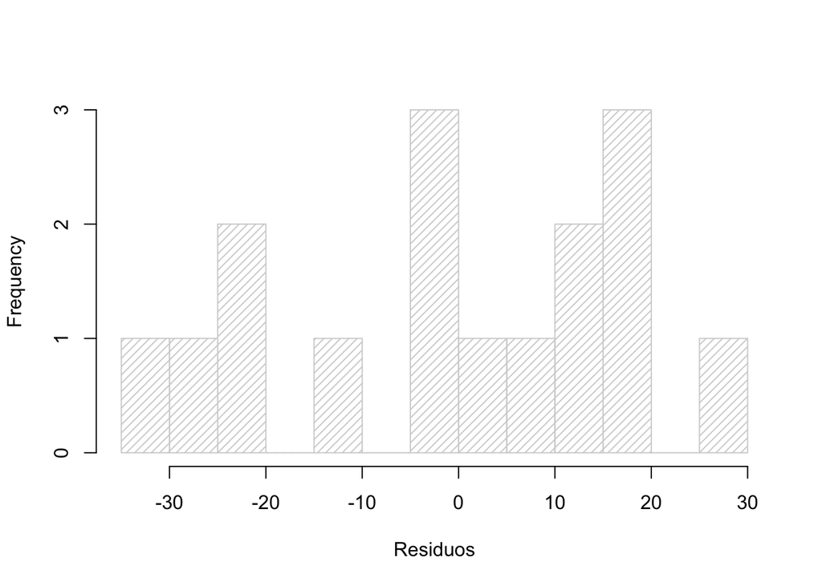

Nos interessa que a distribuição esté perto de uma distribuição normal.

#### (b) Normal probability plot (Q-Q plot)

No q-q plot, os quartis dos residuos e ploteado contra os quartis duma distribuição normal.

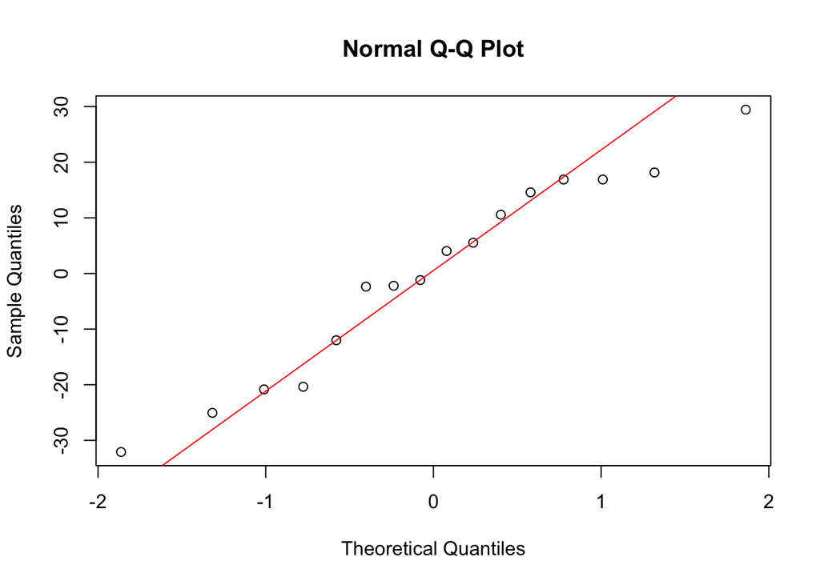

Uma distribuição normal perfeit teria todos os pontos exatamente na linha. No entanto, alguns desvios são esperados, especialmente perto das extremidades (observe o canto superior direito), mas os desvios devem ser pequenos.

#### (c) teste Jarque–Bera

Este teste estatístico para a avaliar a distribuição dos residuos. A sua hipotese nula é que os residuos estão normalmente distribuidos.

```
##
##  Jarque Bera Test
##
## data:  mod3$residuals
## X-squared = 0.82502, df = 2, p-value = 0.662
```

O valor-p do teste é alto, não significativo, pelo que não podemos rejeitar a hipotese nula, concluindo que os residuos estão normalmente distribuidos.

### ii) Homogeneidade de variância dos erros (Homoscedasticity)

#### Plotar residuos contra valores estimados

Por um lado, os residuos deveriam distribuirse a longo do zero, sem criar padrões (ascendentes, descendentes, circulares)

A distribuição dos residuos vertical deveria se uniforme ao longo do eixo x.

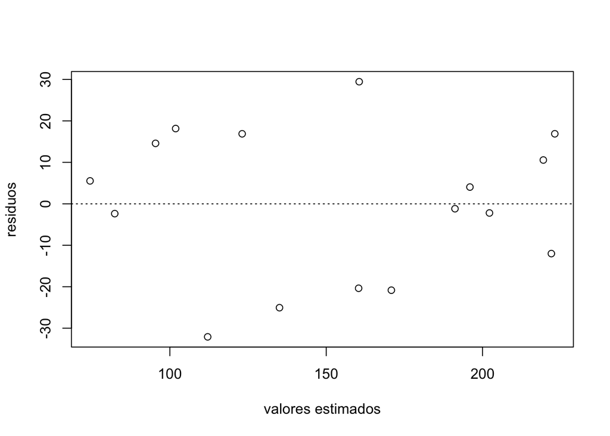

#### Plotar residuos contra IVs

Como no plot residuos/estimados, aqui examinamos variação ao longo da média e diferências variação dos residuos changes

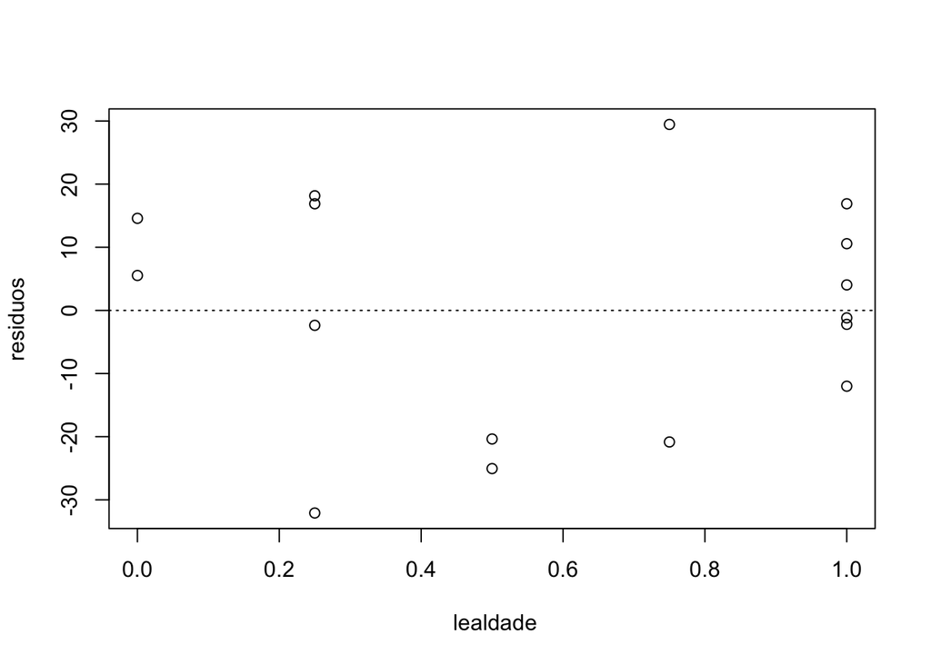

#### Correlações residuos/ VIs

Faça um teste de correlação na variável X e os resíduos.

```
##
##  Pearson's product-moment correlation
##
## data:  D$lealdade and mod3$residuals
## t = 3.2337e-16, df = 14, p-value = 1
## alternative hypothesis: true correlation is not equal to 0
## 95 percent confidence interval:
##  -0.4957053  0.4957053
## sample estimates:
##          cor
## 8.642314e-17
```

o valor p é alto, portanto, a hipótese nula de que a correlação verdadeira é 0 não pode ser rejeitada. Portanto, a suposição é verdadeira para este modelo.

#### Breusch–Pagan teste

Para além dos métodos visuais, também podemos usar este test

```
##
##  Breusch-Pagan test
##
## data:  mod3
## BP = 0.49648, df = 3, p-value = 0.9197
```

A hipotesi nulla neste ‘chi-squared test’ é homoscedasticity.  
Sendo o valor-p alto, não significativo, não rejeitamos a H0 e concluimos que a variancia dos erros é homogenea.

### iii) Independência das variáveis explicativas (multicolinearidade)

- A **Tolerância** é uma medida de multicolinearidade entre as variáveis independentes permitindo determinar a proporção da variação de cada variável independente que não é explicada pelas outras variáveis independentes:
  $$tol_i =1−R^2_i$$

**$R^2_i$**: é o coeficiente de determinação múltiplo, mas neste caso está a tomar-se a variável $X_i$ como dependente e as restantes variáveis $X_i$ mantêm-se como independentes.

- **Variance Inflaction Factor(VIF)**
  $$VIF= 1/1−R^2$$
  logo
  $$VIF= 1/tol_i$$

Se o VIF de uma variável for alto, significa que a informação dessa variável já é explicada por outras variáveis X presentes no modelo dado.  
Portanto, quanto menor o VIF (<2), melhor.

Praticamente, se dois dos Xs tiverem alta correlação, eles provavelmente terão VIFs altos. Geralmente, O VIF para uma variável X deve ser menor que 4 para ser aceito como não causando multicolinearidade. - O corte é mantido tão baixo quanto 2, se quiser ser rigoroso sobre suas variáveis X.

```
##   Variables Tolerance      VIF
## 1  lealdade 0.9147381 1.093209
## 2  sexomale 0.8834595 1.131914
## 3     idade 0.9344135 1.070190
```

Convenção, não temos problemas de multicolinearidade quando  
- $Tol > 0,2$  
- $VIF < 5$

Em caso de multicolinearidade, 2 soluções

1. Remover a VI com o VIF mais alto; ou,
2. Revisar a correlação entre todas as variáveis e manter apenas um de todos os pares altamente correlacionados.

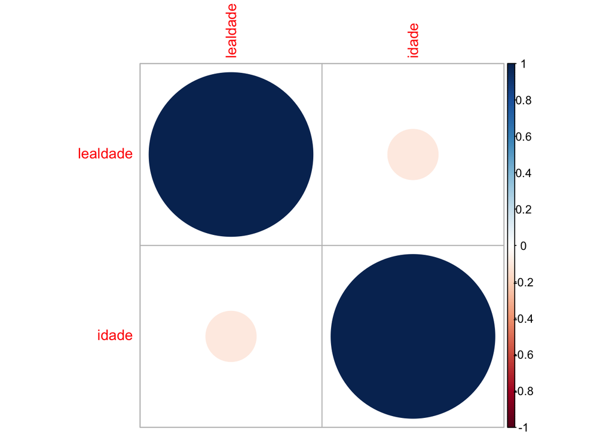

### iv Outliers

Como diagnóstico final, examinar se alguma observação está exercendo influência excessiva nos resultados do modelo.

Se podem considerar três tipos de observaçoes problemáticas

- *outliers* (observações com residuo excessivamente grande),
- *pontos de alavancagem* (observações que tomam um valor de um preditor que está desproporcionalmente distante de outros valores), e
- *pontos de influência* (outliers com muita alavancagem).  
  O mais problemático deles são os pontos de influência porque eles têm a maior capacidade de distorcer os coeficientes de regressão parcial.

Um diagnóstico simples de estas situações e possível com os plots dos residuos que já utilizamos (Normalidade).

- Se se destacar na escala residual, é um *outlier*.
- Se uma observação se destaca na escala do preditor, então ela tem *alavancagem (leverage)*.
- Se se destacar em ambas as dimensões, é um ponto de *influência*.

Outra opção para avaliar estas observações é calcular as quantidades de

- ´Studentized residuals´ para detetar *outliers*,
- ´hat values´para detetar *leverage points*, and
- `Cook’s distances` para detetar observações *influential*.

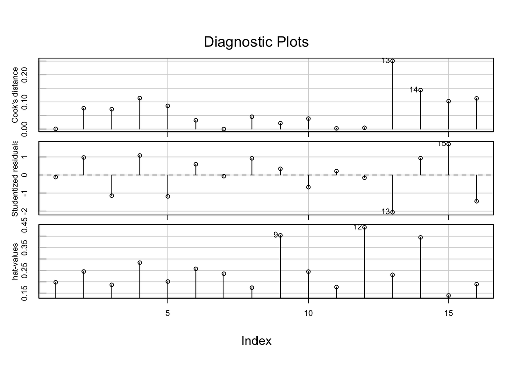

Um valor extremo em relação aos outros indica que uma observação pode ser particularmente problemática. O investigador deve decidir se é razoável manter as observações na análise ou se alguma delas deve ser removida.